# BayesTimeSeriesFull

## Bayesian Time Series

[figure not shown]

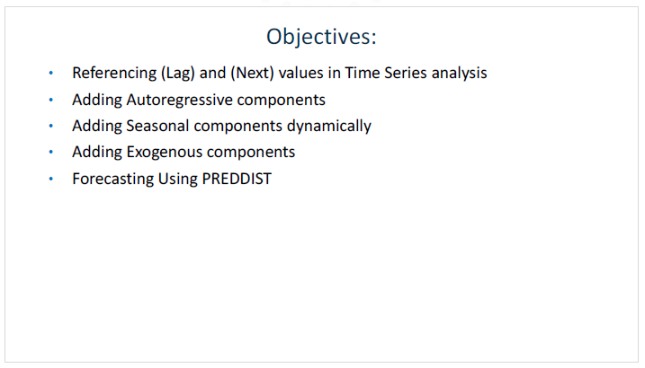

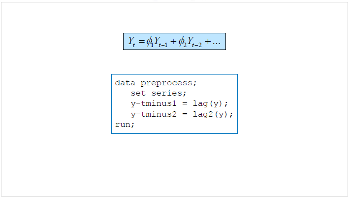

Let’s begin our discussion of Bayesian time series structure with autoregressive elements. Prior to SAS/STAT 14.1, coding these elements was more time consuming than it is now. To fit autoregressive time series models in the past, you had to preprocess the data. This put the work on you to create variables within the data set that contained the lagged values of the response series.

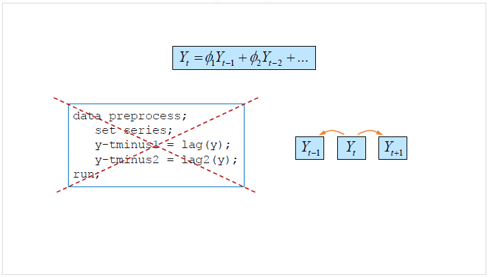

Now, we have access to lead and lagged values for random variables that are indexed. What do I mean by indexed? Two types of random variables are indexed in the MCMC procedure.

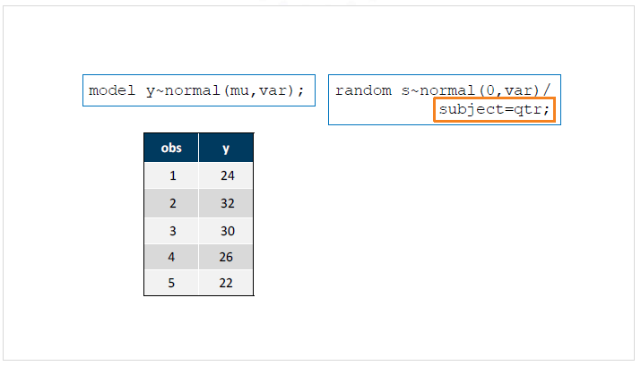

The first is the response variable, our time series. In the MODEL statement, this variable is indexed by observations. The second is a random variable placed in the RANDOM statement. This variable is indexed by the SUBJECT= option.

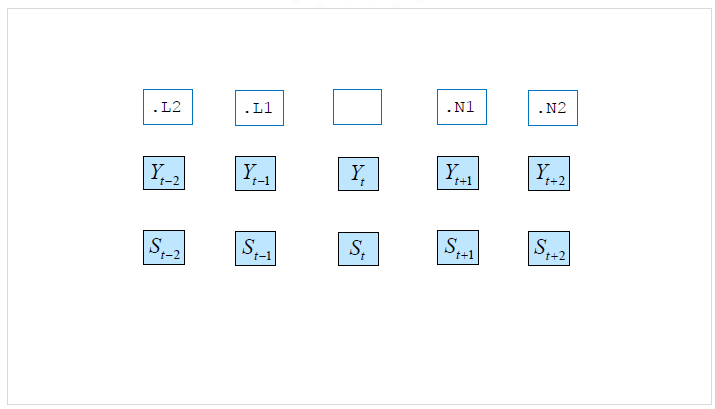

To access both the lead and lagged values of these indexed variables, we state the variable name followed by either .L or .N to access lagged or next values respectively. Let’s look at an example.

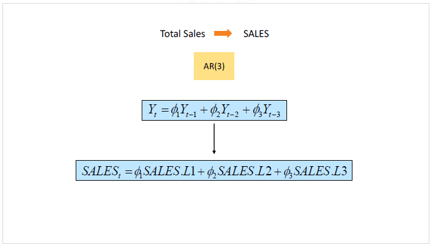

Suppose you have a time series of total sales data accumulated monthly. During your exploration, you determine that a thirdorder autoregressive model (AR(3)) would be appropriate for your series. So, three lagged values of the response series would be included in your time series model. When adding these elements to our model, we would code SALES.L1 for the first lagged value, SALES.L2 for the second, and SALES.L3 for the third. We do not use it here, but if we wanted to look forward in time, we would use SALES.N1 to access the value one time unit ahead in the series. Creating these lagged values using a data set was not too complex, but with .L and .N, it is much easier. However, there was no built-in way to account for the initial states of these lagged variables. What do I mean by initial states?

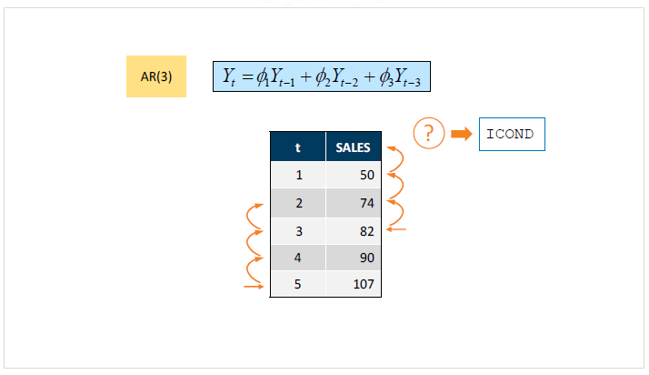

To forecast the total sales at time position 5 in the series, we would include the values from time positions 4, 3, and 2. This is not a problem because those values are found within our response series. What happens if we wanted to forecast position 3 in the series? We have the total sales of time positions 2 and 1. You might now see the problem that we have. As we approach the start of the time series, we run out of information for our lagged time values. This was a problem before the ICOND= option. In the MODEL statement or the RANDOM statement, we can now account for these initial states (or initial conditions).

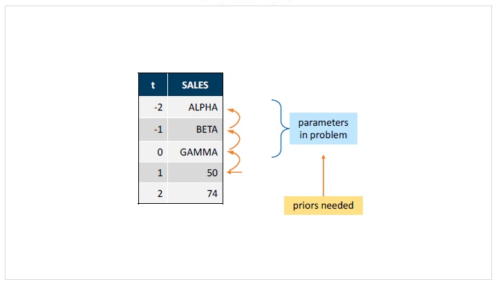

In our example, we can include ICOND= (alpha beta gamma) in the MODEL statement. These initial states are treated as parameters in the problem, and we place priors against them just like any other parameter in our model. Three items are listed due to the maximum number of initial states needed being three when we are at the very beginning of the series. Using this technique, we do not lose data at the front from missing values.

```
SAS server started using Context SAS Studio compute context with SESSION_ID=93dd6aec-4b16-49c0-9d4d-cb4d015701c2-ses0000
```

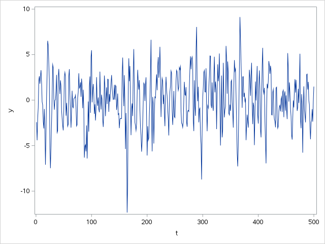

```sas
*Creating AR(4) data set;

%let N = 500;
%let p = 4;
%let sigma=2;
%let constant = 0;
data ar4(keep= t y);
  call streaminit(12345);
  array phi phi1 - phi&p (.8, -.64, .512, -.4096);
  array yLag   yLag1 - yLag&p;
  do j = 1 to dim(yLag);
    yLag[j] = 0;
  end;
  constant=&constant;
  do t = -100 to &N;
    e = rand('normal',0,&sigma);
    y = e;
    do j = 1 to dim(phi);
      y = y + phi[j] * yLag[j];
    end;
    y=y+constant;
    if t > 0 then output;
    do j = dim(yLag) to 2 by -1;
      yLag[j] = yLag[j-1];
    end;
    yLag[1] = y;
  end;
run;


ods graphics on;
proc sgplot data=ar4;
  series x=t y=y;
run;
```

The SAS System

The MCMC Procedure

| Number of Observations Read Number of Observations Used | 500 500 |
| --- | --- |

| Parameters Block | Parameters Parameter | Parameters Sampling Method | Parameters Threads | Parameters Initial Value | Parameters Prior Distribution |
| --- | --- | --- | --- | --- | --- |
| 1 | phi_1 | N-Metropolis | 8 | 0 | normal(0,var=1000) |
|  | phi_2 |  |  | 0 | normal(0,var=1000) |
|  | phi_3 |  |  | 0 | normal(0,var=1000) |
|  | phi_4 |  |  | 0 | normal(0,var=1000) |
| 2 | sigma2 | N-Metropolis | 8 | 1.0000 | igamma(shape = 3/10, scale = 10/3) |
| 3 | Y_0 | N-Metropolis | 8 | 0 | normal(0, var=1000 ) |
|  | Y_1 |  |  | 0 | normal(0, var=1000 ) |
|  | Y_2 |  |  | 0 | normal(0, var=1000 ) |
|  | Y_3 |  |  | 0 | normal(0, var=1000 ) |

The SAS System

The MCMC Procedure

| Posterior Summaries and Intervals Parameter | Posterior Summaries and Intervals N | Posterior Summaries and Intervals Mean | Posterior Summaries and Intervals Standard Deviation | Posterior Summaries and Intervals 95% HPD Interval | Posterior Summaries and Intervals 95% HPD Interval |
| --- | --- | --- | --- | --- | --- |
| phi_1 | 100000 | 0.8382 | 0.0411 | 0.7584 | 0.9184 |
| phi_2 | 100000 | -0.5762 | 0.0518 | -0.6749 | -0.4729 |
| phi_3 | 100000 | 0.4835 | 0.0519 | 0.3815 | 0.5847 |
| phi_4 | 100000 | -0.3951 | 0.0414 | -0.4773 | -0.3153 |
| sigma2 | 100000 | 4.1109 | 0.2641 | 3.6000 | 4.6336 |
| Y_0 | 100000 | 1.2669 | 5.0179 | -8.7476 | 11.0021 |
| Y_1 | 100000 | 0.6614 | 7.9088 | -15.0633 | 16.2767 |
| Y_2 | 100000 | 4.4767 | 7.9868 | -11.0639 | 20.6039 |
| Y_3 | 100000 | 13.0851 | 8.4739 | -3.3648 | 29.8601 |

The SAS System

The MCMC Procedure

| Effective Sample Sizes Parameter | Effective Sample Sizes ESS | Effective Sample Sizes Autocorrelation Time | Effective Sample Sizes Efficiency |
| --- | --- | --- | --- |
| phi_1 | 6244.6 | 16.0140 | 0.0624 |
| phi_2 | 6271.0 | 15.9465 | 0.0627 |
| phi_3 | 6002.0 | 16.6612 | 0.0600 |
| phi_4 | 5626.9 | 17.7716 | 0.0563 |
| sigma2 | 17163.8 | 5.8262 | 0.1716 |
| Y_0 | 5997.8 | 16.6728 | 0.0600 |
| Y_1 | 5272.0 | 18.9682 | 0.0527 |
| Y_2 | 6358.4 | 15.7273 | 0.0636 |
| Y_3 | 6677.8 | 14.9749 | 0.0668 |

The SAS System

The MCMC Procedure

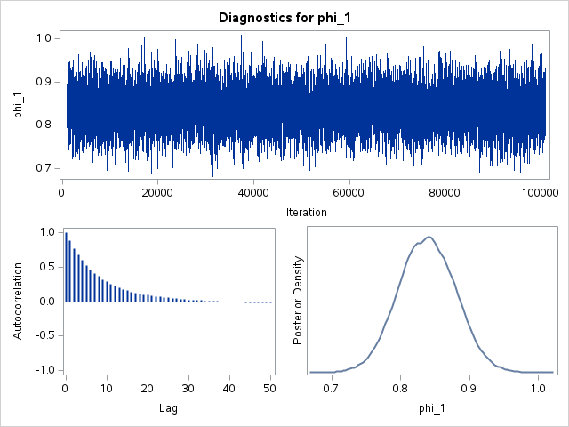

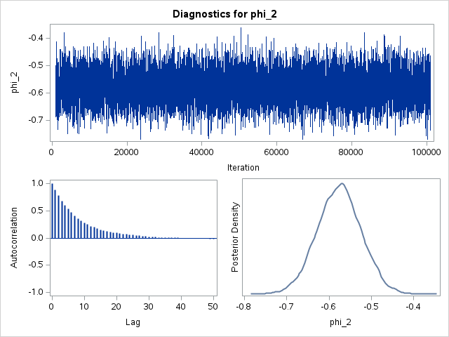

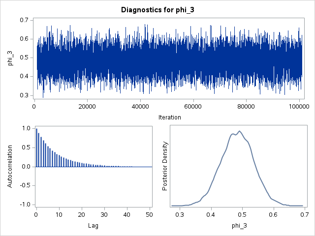

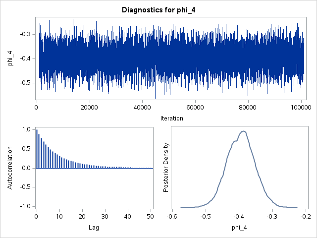

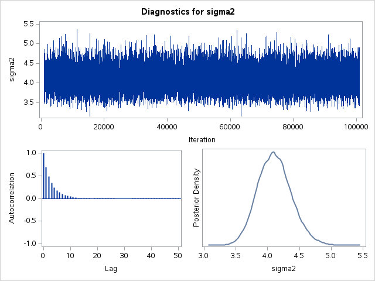

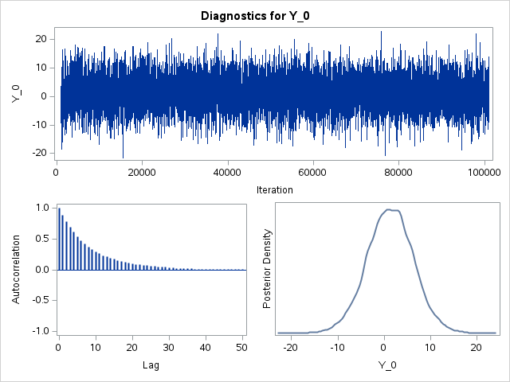

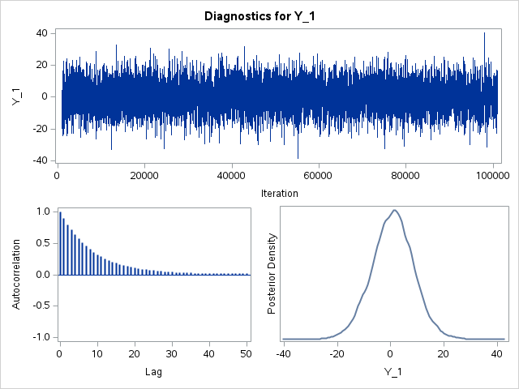

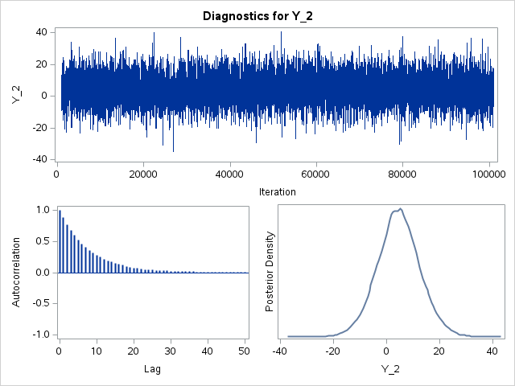

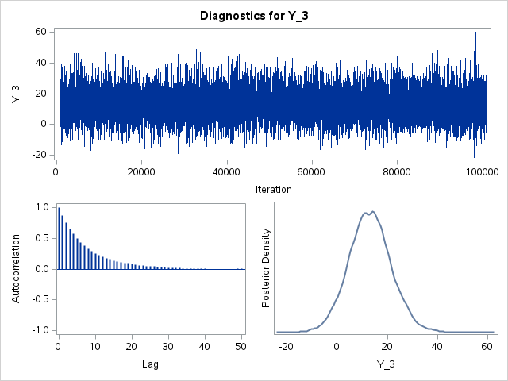

The SAS System

The CONTENTS Procedure

| Data Set Name | WORK.AR4EXAMPLE | Observations | 100000 |
| --- | --- | --- | --- |
| Member Type | DATA | Variables | 13 |
| Engine | V9 | Indexes | 0 |
| Created | 04/15/2025 14:22:03 | Observation Length | 104 |
| Last Modified | 04/15/2025 14:22:03 | Deleted Observations | 0 |
| Protection |  | Compressed | NO |
| Data Set Type |  | Sorted | NO |
| Label |  |  |  |
| Data Representation | SOLARIS_X86_64, LINUX_X86_64, ALPHA_TRU64, LINUX_IA64, LINUX_POWER_64 |  |  |
| Encoding | utf-8 Unicode (UTF-8) |  |  |

| Engine/Host Dependent Information |  |
| --- | --- |
| Data Set Page Size | 65536 |
| Number of Data Set Pages | 160 |
| First Data Page | 1 |
| Max Obs per Page | 629 |
| Obs in First Data Page | 595 |
| Number of Data Set Repairs | 0 |
| Filename | /opt/sas/viya/config/var/tmp/compsrv/default/93dd6aec-4b16-49c0-9d4d-cb4d015701c2/SAS_workEEB80000020B_sas-compute-server-a5564084-adbf-4dd6-816f-56d632996a06-16126/ar4example.sas7bdat |
| Release Created | V.0400M0 |
| Host Created | Linux |
| Inode Number | 35007694 |
| Access Permission | rw-r--r-- |
| Owner Name | UNKNOWN |
| File Size | 10MB |
| File Size (bytes) | 10551296 |

| Alphabetic List of Variables and Attributes # | Alphabetic List of Variables and Attributes Variable | Alphabetic List of Variables and Attributes Type | Alphabetic List of Variables and Attributes Len | Alphabetic List of Variables and Attributes Format | Alphabetic List of Variables and Attributes Label |
| --- | --- | --- | --- | --- | --- |
| 1 | Iteration | Num | 8 | 8. |  |
| 12 | LogLike | Num | 8 | D8. | Log-Likelihood Value |
| 13 | LogPost | Num | 8 | D8. | Log Posterior Density |
| 11 | LogPrior | Num | 8 | D8. | Log Prior Density |
| 7 | Y_0 | Num | 8 | D8. |  |
| 8 | Y_1 | Num | 8 | D8. |  |
| 9 | Y_2 | Num | 8 | D8. |  |
| 10 | Y_3 | Num | 8 | D8. |  |
| 2 | phi_1 | Num | 8 | D8. |  |
| 3 | phi_2 | Num | 8 | D8. |  |
| 4 | phi_3 | Num | 8 | D8. |  |
| 5 | phi_4 | Num | 8 | D8. |  |
| 6 | sigma2 | Num | 8 | D8. |  |

```sas
*AR(4) Analysis;

proc mcmc data=ar4 nmc=100000 seed=100 nthreads=8 propcov=quanew
       outpost=ar4example;
  parms phi_1 phi_2 phi_3 phi_4;
  parms sigma2 1;
  parms Y_0 Y_1 Y_2 Y_3;
  prior phi_:~normal(0,var=1000);
  prior sigma2 ~ igamma(shape = 3/10, scale = 10/3);
  prior Y_: ~ n(0, var=1000 );
  mu=phi_1*y.l1 + phi_2*y.l2 + phi_3*y.l3 + phi_4*y.l4;
  model y~normal(mu, var=sigma2)
        icond=(Y_3 Y_2 Y_1 Y_0);
run;

proc contents data=ar4example;
run;
```

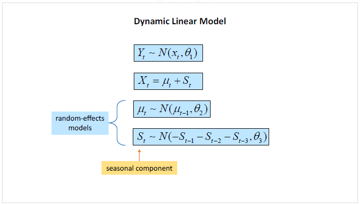

Performing a Bayesian time series analysis also enables you to use a dynamic linear model setup. This setup is a very general type of nonstationary time series model. With this, you can create models with time-varying coefficients where you can explore stochastic shifts in regression parameters. To do this, we use random-effects models that specify time dependence between successive parameter values in the form of smoothness priors. The best application of this structure is for seasonality components.

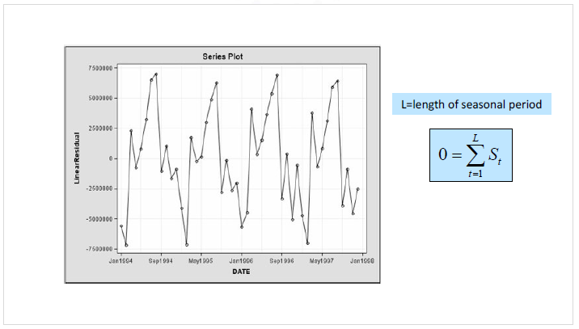

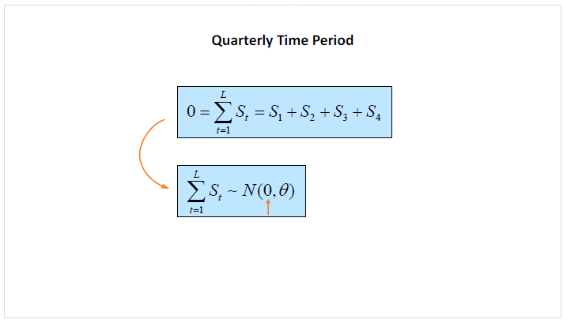

From a deterministic approach, these quarterly seasonal component values will sum to zero across four consecutive time points. This is due to the period of quarterly data being 4 in length. Taking a more dynamic approach, this sum is zero in the mean of the distribution with an additional variability.

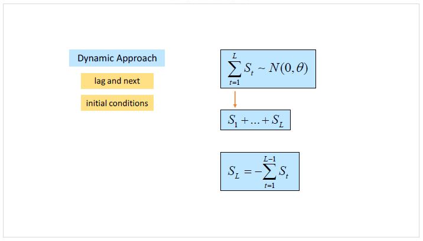

The additional benefit of using the dynamic approach to this seasonal component is that we can now use the lag and next elements as well as initial conditions during the modeling process. Because we know that the sum of all the seasonal components should add to zero in the mean, we can model the seasonal component at the current time point as the sum of the negative previous seasonal components.

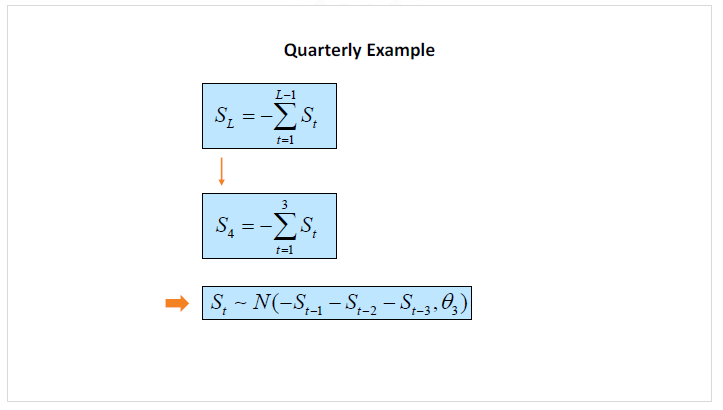

In our quarterly example, this would make the value of our current time point equal to the negative of the sum of the previous three seasonal components. We place this calculation in the mean of our distribution with a smoothness variance component.

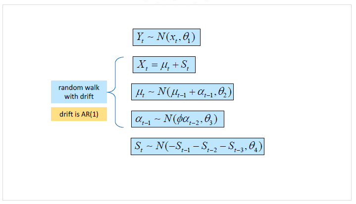

In addition to seasonality components, we could entertain trends that follow a random walk with drift. This drift could follow a first-order autoregressive process. The application of dynamic linear model setups within our time series models greatly expands the ability of our Bayesian approach to modeling.

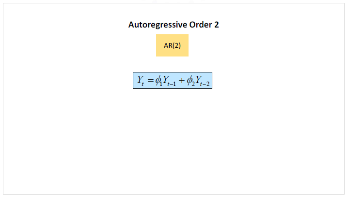

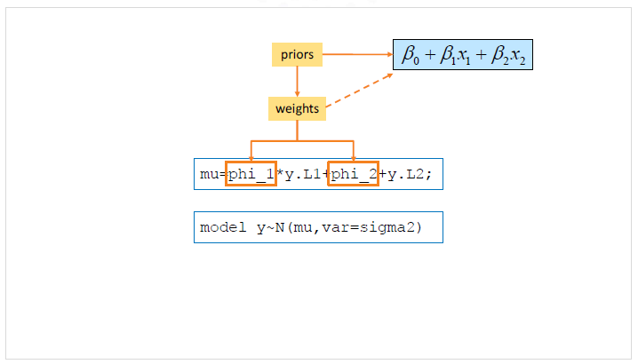

As you recall, prior to the model line in our code, we composed the mean from a weighted combination of the previous two values of the time series. The phi coefficients in the model were the weights. Think back to traditional regression equations from your past. You might see a resemblance of this autoregressive setup to that of a regression equation. In the regression version, our weights/coefficients are our beta estimates. Much like in the autoregressive viewpoint, we place prior distributions against the coefficients, as they are the parameters of the problem.

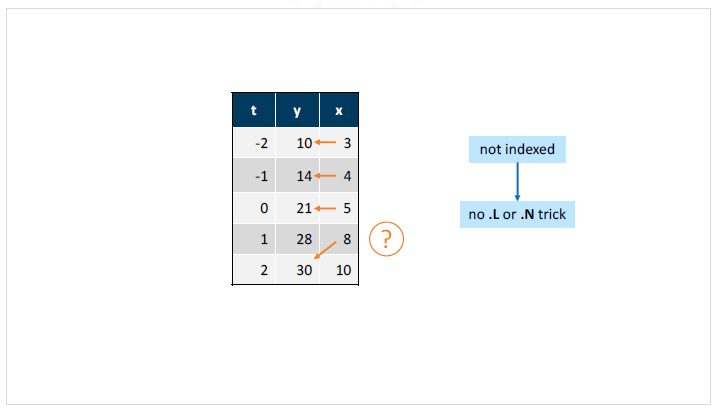

Adding a contemporaneous exogenous effect, where x at time t affects y at time t, is rather simple. However, what happens if there is a lag of the exogenous variable that influences the value of the series at time t? Unlike the series y and our seasonal components from before, our exogenous variable does not appear on a code line that makes it indexed. Therefore, we do not have the luxury of the .L and .N elements. So how do we bring in these lagged values on an exogenous variable?